# Churn Analysis

Nanda kishore

2023-12-03

### AIM:

Business Goals

Churn refers to customers who have exited within the last month, significantly impacting both sales figures and overall business revenue. The root cause of this phenomenon often lies in customer satisfaction levels. Therefore, the business objectives should focus on minimizing customer churn to boost revenue and enhancing overall customer satisfaction.

To effectively address customer churn, it becomes imperative to predict which customers are at a higher risk of churning by identifying early indicators across various sales channels.

*The key challenge is to predict if an individual customer will churn or not.* *The extra challenge is to identify the key components of churning.*

### questions for exploration include:

- Are there discernible patterns among churned customers?
- What is the percentage distribution between churned and existing customers?
- How are contract types distributed among customers?
- Which variables exhibit correlation with customer churn?
- Conversely, which variables do not display correlation with customer churn?
- What model proves most accurate in predicting churn?
- How are contract types distributed within the customer base?
- What impact does contract length have on customer behavior?
- Is there a relationship between customer usage patterns, additional products, and churn?
- How does the variety of services a customer utilizes influence churn?

### About Dataset

#### Context

“Predict behavior to retain customers. You can analyze all relevant customer data and develop focused customer retention programs.” [IBM Sample Data Sets]

#### Content

Each row represents a customer, each column contains customer’s attributes described on the column Metadata.

#### The data set includes information about:

- Customers who left within the last month – the column is called Churn
- Services that each customer has signed up for – phone, multiple lines, internet, online security, online backup, device protection, tech support, and streaming TV and movies
- Customer account information – how long they’ve been a customer, contract, payment method, paperless billing, monthly charges, and total charges
- Demographic info about customers – gender, age range, and if they have partners and dependents

#### Dataset Attributes

- customerID - Customer ID
- gender - Whether the customer is a male or a female
- SeniorCitizen - Whether the customer is a senior citizen (1, 0)
- Partner - Whether the customer has a partner (Yes, No)
- Dependents - Whether the customer has dependents (Yes, No)
- tenure - Number of months the customer has stayed with the company
- PhoneService - Whether the customer has a phone service (Yes, No)
- MultipleLines - Whether the customer has multiple lines (Yes, No, No phone service)
- InternetService - Customer’s internet service provider (DSL, Fiber optic, No)
- OnlineSecurity - Whether the customer has online security (Yes, No, No internet service)
- OnlineBackup - Whether the customer has online backup or not (Yes, No, No internet service)
- DeviceProtection - Whether the customer has device protection (Yes, No, No internet service)
- TechSupport - Whether the customer has tech support (Yes, No, No internet service)
- StreamingTV - Whether the customer has streaming TV service (Yes, No, No internet service)
- StreamingMovies - Whether the customer has streaming movies service (Yes, No, No internet service)
- Contract - Indicates the type of the contract (Month-to-month, One year, Two years)
- PaperlessBilling - Whether the customer has paperless billing (Yes, No)
- PaymentMethod - Indicates the payment method (Electronic check, Mailed check, Bank transfer (automatic), Credit card (automatic))
- MonthlyCharges - Indicates the current monthly subscription cost of the customer
- TotalCharges - Indicates the total charges paid by the customer so far
- Churn - Indicates whether the customer churned

reference [kaggle](https://www.kaggle.com/datasets/blastchar/telco-customer-churn/)

### Loading Dataset

```r
file_path <- "C:/Users/manda/OneDrive - Western Michigan University/Desktop/wmu/fall 2023/applied data minnig/project/WA_Fn-UseC_-Telco-Customer-Churn"

# Read the CSV file into a data frame
setwd("C:/Users/manda/OneDrive - Western Michigan University/Desktop/wmu/fall 2023/applied data minnig/project/")
df <- read.csv("WA_Fn-UseC_-Telco-Customer-Churn.csv")

# View the structure of the data frame
str(df)
```

```
## 'data.frame':    7043 obs. of  21 variables:
##  $ customerID      : chr  "7590-VHVEG" "5575-GNVDE" "3668-QPYBK" "7795-CFOCW" ...
##  $ gender          : chr  "Female" "Male" "Male" "Male" ...
##  $ SeniorCitizen   : int  0 0 0 0 0 0 0 0 0 0 ...
##  $ Partner         : chr  "Yes" "No" "No" "No" ...
##  $ Dependents      : chr  "No" "No" "No" "No" ...
##  $ tenure          : int  1 34 2 45 2 8 22 10 28 62 ...
##  $ PhoneService    : chr  "No" "Yes" "Yes" "No" ...
##  $ MultipleLines   : chr  "No phone service" "No" "No" "No phone service" ...
##  $ InternetService : chr  "DSL" "DSL" "DSL" "DSL" ...
##  $ OnlineSecurity  : chr  "No" "Yes" "Yes" "Yes" ...
##  $ OnlineBackup    : chr  "Yes" "No" "Yes" "No" ...
##  $ DeviceProtection: chr  "No" "Yes" "No" "Yes" ...
##  $ TechSupport     : chr  "No" "No" "No" "Yes" ...
##  $ StreamingTV     : chr  "No" "No" "No" "No" ...
##  $ StreamingMovies : chr  "No" "No" "No" "No" ...
##  $ Contract        : chr  "Month-to-month" "One year" "Month-to-month" "One year" ...
##  $ PaperlessBilling: chr  "Yes" "No" "Yes" "No" ...
##  $ PaymentMethod   : chr  "Electronic check" "Mailed check" "Mailed check" "Bank transfer (automatic)" ...
##  $ MonthlyCharges  : num  29.9 57 53.9 42.3 70.7 ...
##  $ TotalCharges    : num  29.9 1889.5 108.2 1840.8 151.7 ...
##  $ Churn           : chr  "No" "No" "Yes" "No" ...
```

```r
#Data Exploration

summary(df)
```

```
##   customerID           gender          SeniorCitizen      Partner
##  Length:7043        Length:7043        Min.   :0.0000   Length:7043
##  Class :character   Class :character   1st Qu.:0.0000   Class :character
##  Mode  :character   Mode  :character   Median :0.0000   Mode  :character
##                                        Mean   :0.1621
##                                        3rd Qu.:0.0000
##                                        Max.   :1.0000
##
##   Dependents            tenure      PhoneService       MultipleLines
##  Length:7043        Min.   : 0.00   Length:7043        Length:7043
##  Class :character   1st Qu.: 9.00   Class :character   Class :character
##  Mode  :character   Median :29.00   Mode  :character   Mode  :character
##                     Mean   :32.37
##                     3rd Qu.:55.00
##                     Max.   :72.00
##
##  InternetService    OnlineSecurity     OnlineBackup       DeviceProtection
##  Length:7043        Length:7043        Length:7043        Length:7043
##  Class :character   Class :character   Class :character   Class :character
##  Mode  :character   Mode  :character   Mode  :character   Mode  :character
##
##
##
##
##  TechSupport        StreamingTV        StreamingMovies      Contract
##  Length:7043        Length:7043        Length:7043        Length:7043
##  Class :character   Class :character   Class :character   Class :character
##  Mode  :character   Mode  :character   Mode  :character   Mode  :character
##
##
##
##
##  PaperlessBilling   PaymentMethod      MonthlyCharges    TotalCharges
##  Length:7043        Length:7043        Min.   : 18.25   Min.   :  18.8
##  Class :character   Class :character   1st Qu.: 35.50   1st Qu.: 401.4
##  Mode  :character   Mode  :character   Median : 70.35   Median :1397.5
##                                        Mean   : 64.76   Mean   :2283.3
##                                        3rd Qu.: 89.85   3rd Qu.:3794.7
##                                        Max.   :118.75   Max.   :8684.8
##                                                         NA's   :11
##     Churn
##  Length:7043
##  Class :character
##  Mode  :character
##
##
##
##
```

### pre processing the data

- before everything else we remove the customer id in order for better analysis

```r
df <- df[, !(names(df) %in% c("customerID"))]
```

#### missing values

```r
# Check for missing values in each column
missing_values <- colSums(is.na(df))

# Display the results
print(missing_values)
```

```
##           gender    SeniorCitizen          Partner       Dependents
##                0                0                0                0
##           tenure     PhoneService    MultipleLines  InternetService
##                0                0                0                0
##   OnlineSecurity     OnlineBackup DeviceProtection      TechSupport
##                0                0                0                0
##      StreamingTV  StreamingMovies         Contract PaperlessBilling
##                0                0                0                0
##    PaymentMethod   MonthlyCharges     TotalCharges            Churn
##                0                0               11                0
```

```r
# 11 missing values in Total charges

# Impute missing values in 'TotalCharges' with the mean
df$TotalCharges[is.na(df$TotalCharges)] <- mean(df$TotalCharges, na.rm = TRUE)

#or

df$TotalCharges[is.na(df$TotalCharges)] <- 0

# Check for missing values in each column
missing_values <- colSums(is.na(df))

# Display the results
print(missing_values)
```

```
##           gender    SeniorCitizen          Partner       Dependents
##                0                0                0                0
##           tenure     PhoneService    MultipleLines  InternetService
##                0                0                0                0
##   OnlineSecurity     OnlineBackup DeviceProtection      TechSupport
##                0                0                0                0
##      StreamingTV  StreamingMovies         Contract PaperlessBilling
##                0                0                0                0
##    PaymentMethod   MonthlyCharges     TotalCharges            Churn
##                0                0                0                0
```

- no missing values

#### duplicate values

```r
# Check for duplicated rows in the data frame
num_duplicated <- sum(duplicated(df))

# Print the number of duplicated values
print(paste("Number of duplicated values in the dataset: ", num_duplicated))
```

```
## [1] "Number of duplicated values in the dataset:  22"
```

```r
df <- unique(df)

# Check for duplicated rows in the data frame
num_duplicated <- sum(duplicated(df))

# Print the number of duplicated values
print(paste("Number of duplicated values in the dataset: ", num_duplicated))
```

```
## [1] "Number of duplicated values in the dataset:  0"
```

```r
columns <- names(df)

numeric_columns <- character(0)
binary_columns <- character(0)
categorical_columns <- character(0)

for (col in columns) {
  unique_vals <- unique(df[[col]])

  if (length(unique_vals) > 10) {
    numeric_columns <- c(numeric_columns, col)
  } else if (length(unique_vals) == 2) {
    binary_columns <- c(binary_columns, col)
  } else {
    categorical_columns <- c(categorical_columns, col)
  }
}

# Print the categorization
cat("Numeric Columns:", numeric_columns, "\n")
```

```
## Numeric Columns: tenure MonthlyCharges TotalCharges
```

```r
cat("Binary Columns:", binary_columns, "\n")
```

```
## Binary Columns: gender SeniorCitizen Partner Dependents PhoneService PaperlessBilling Churn
```

```r
cat("Categorical Columns:", categorical_columns, "\n")
```

```
## Categorical Columns: MultipleLines InternetService OnlineSecurity OnlineBackup DeviceProtection TechSupport StreamingTV StreamingMovies Contract PaymentMethod
```

```r
# Copy the data frame
df1 <- df

# Identify categorical columns
categoric_columns <- c("gender", "Partner", "Dependents", "PhoneService",
                        "MultipleLines", "InternetService", "OnlineSecurity",
                        "OnlineBackup", "DeviceProtection", "TechSupport",
                        "StreamingTV", "StreamingMovies", "Contract",
                        "PaperlessBilling", "PaymentMethod")

# Convert categorical columns to factors
df1[categoric_columns] <- lapply(df1[categoric_columns], factor)

# Convert 'Churn' column to factor
df1$Churn <- factor(df1$Churn, levels = c("No", "Yes"))

# Print the first few rows of the transformed data frame
head(df1)
```

```
##   gender SeniorCitizen Partner Dependents tenure PhoneService    MultipleLines
## 1 Female             0     Yes         No      1           No No phone service
## 2   Male             0      No         No     34          Yes               No
## 3   Male             0      No         No      2          Yes               No
## 4   Male             0      No         No     45           No No phone service
## 5 Female             0      No         No      2          Yes               No
## 6 Female             0      No         No      8          Yes              Yes
##   InternetService OnlineSecurity OnlineBackup DeviceProtection TechSupport
## 1             DSL             No          Yes               No          No
## 2             DSL            Yes           No              Yes          No
## 3             DSL            Yes          Yes               No          No
## 4             DSL            Yes           No              Yes         Yes
## 5     Fiber optic             No           No               No          No
## 6     Fiber optic             No           No              Yes          No
##   StreamingTV StreamingMovies       Contract PaperlessBilling
## 1          No              No Month-to-month              Yes
## 2          No              No       One year               No
## 3          No              No Month-to-month              Yes
## 4          No              No       One year               No
## 5          No              No Month-to-month              Yes
## 6         Yes             Yes Month-to-month              Yes
##               PaymentMethod MonthlyCharges TotalCharges Churn
## 1          Electronic check          29.85        29.85    No
## 2              Mailed check          56.95      1889.50    No
## 3              Mailed check          53.85       108.15   Yes
## 4 Bank transfer (automatic)          42.30      1840.75    No
## 5          Electronic check          70.70       151.65   Yes
## 6          Electronic check          99.65       820.50   Yes
```

```r
summary(df[, numeric_columns])
```

```
##      tenure      MonthlyCharges    TotalCharges
##  Min.   : 0.00   Min.   : 18.25   Min.   :  18.8
##  1st Qu.: 9.00   1st Qu.: 35.75   1st Qu.: 411.1
##  Median :29.00   Median : 70.40   Median :1410.2
##  Mean   :32.47   Mean   : 64.85   Mean   :2290.3
##  3rd Qu.:55.00   3rd Qu.: 89.90   3rd Qu.:3801.7
##  Max.   :72.00   Max.   :118.75   Max.   :8684.8
```

[figure not shown]

```r
library(ggplot2)
# Data imbalance check
churn_counts <- table(df$Churn)
pie_values <- prop.table(churn_counts) * 100

# Plotting
par(mfrow = c(1, 2), mar = c(5, 5, 2, 2))

# Pie chart
pie(pie_values, labels = c('Not-Churn Customers', 'Churn Customers'),
    col = c('#1F78B4', '#33A02C'), main = 'Churn and Not-Churn Customers %',
    cex.main = 1, cex.lab = 1)

# Bar chart
bar_colors <- c('#1F78B4', '#33A02C')
barplot(churn_counts, names.arg = c('Not-Churn Customers', 'Churn Customers'),
        col = bar_colors, main = 'Churn and Not-Churn Customers',
        cex.main = 1, cex.lab = 1, border = 'black')

# Adding percentage labels to the pie chart
text(0, 0, paste0(sprintf("%.2f", pie_values[1]), "%"), col = 'white', cex = 1.5)
text(0, 0, 'Not-Churn Customers', col = 'black', cex = 1, pos = 4)

text(1, 0, paste0(sprintf("%.2f", pie_values[2]), "%"), col = 'white', cex = 1.5)
text(1, 0, 'Churn Customers', col = 'black', cex = 1, pos = 4)
```

```r
# Install the e1071 package if not already installed
if (!requireNamespace("e1071", quietly = TRUE)) {
  install.packages("e1071")
}

# Load the e1071 package
library(e1071)
```

```
##
## Distribution for each numerical feature
```

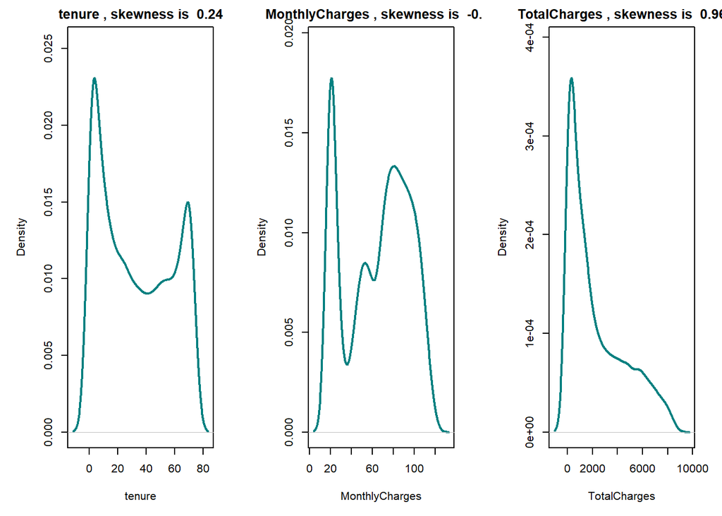

```r
# Assuming df1 is your data frame

dist_custom <- function(dataset, columns_list, rows, cols, suptitle) {
  par(mfrow = c(rows, cols), mar = c(5, 5, 2, 2))
  cat("\n")
  cat(suptitle, "\n", sep = "")

  for (i in seq_along(columns_list)) {
    col <- columns_list[i]

    # Density plot
    plot(density(dataset[[col]]), main = paste(col, ", skewness is ", round(e1071::skewness(dataset[[col]], na.rm = TRUE), 2)),
         col = '#008080', lwd = 2, ylim = c(0, max(density(dataset[[col]])$y) * 1.1),
         xlab = col, ylab = 'Density')
  }
}

# Usage
dist_custom(dataset = df, columns_list = numeric_columns, rows = 1, cols = 3, suptitle = 'Distribution for each numerical feature')
```

```
##
## Boxplots for numerical features
```

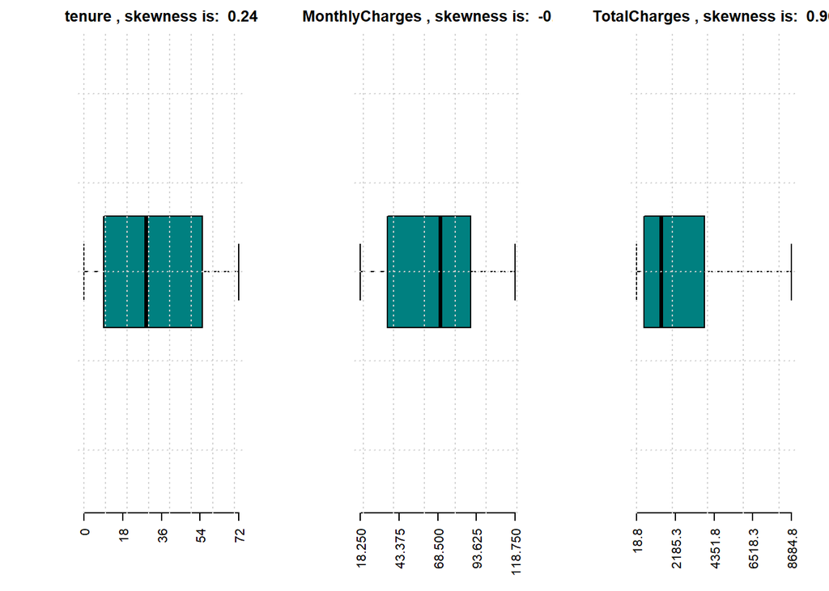

```r
# Assuming df1 is your data frame

boxplots_custom <- function(dataset, columns_list, rows, cols, suptitle) {
  par(mfrow = c(rows, cols), mar = c(5, 5, 2, 2))
  cat("\n")
  cat(suptitle, "\n", sep = "")

  for (i in seq_along(columns_list)) {
    col <- columns_list[i]

    # Boxplot
    boxplot(dataset[[col]], horizontal = TRUE, main = paste(col, ", skewness is: ", round(e1071::skewness(dataset[[col]], na.rm = TRUE), 2)),
            col = '#008080', border = 'black', axes = FALSE, boxwex = 0.5)

    # Add labels and grid
    axis(1, at = seq(min(dataset[[col]]), max(dataset[[col]]), length = 5), las = 2)
    grid()
  }
}


boxplots_custom(dataset = df1, columns_list = numeric_columns, rows = 1, cols = 3, suptitle = 'Boxplots for numerical features')
```

- TotalCharges is rightly skewed.

```r
detect_outliers_iqr <- function(data) {
  # Calculate the first quartile (Q1) and third quartile (Q3)
  Q1 <- quantile(data, 0.25, na.rm = TRUE)
  Q3 <- quantile(data, 0.75, na.rm = TRUE)

  # Calculate the IQR
  IQR <- Q3 - Q1

  # Define the lower and upper bounds to identify outliers
  lower_bound <- Q1 - 1.5 * IQR
  upper_bound <- Q3 + 1.5 * IQR

  # Find the outliers
  outliers <- data[data < lower_bound | data > upper_bound]

  return(outliers)
}

# Apply outlier detection to all numerical columns
outliers_by_column <- list()

for (column in numeric_columns) {
  data_column <- df1[[column]]
  outliers <- detect_outliers_iqr(data_column)
  outliers_by_column[[column]] <- outliers
}

# Print the outliers for each column
for (column in names(outliers_by_column)) {
  cat("Outliers in", column, ":", outliers_by_column[[column]], "\n")
}
```

```
## Outliers in tenure :
## Outliers in MonthlyCharges :
## Outliers in TotalCharges :
```

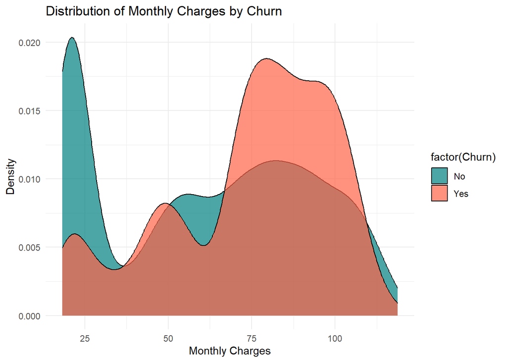

```r
#install.packages("ggplot2")

library(ggplot2)

# Monthly Charges vs Churn
ggplot(df1, aes(x = MonthlyCharges, fill = factor(Churn))) +
  geom_density(alpha = 0.7, color = 'black') +
  scale_fill_manual(values = c('#008080', '#FF6347')) +
  labs(title = 'Distribution of Monthly Charges by Churn', x = 'Monthly Charges', y = 'Density') +
  theme_minimal()
```

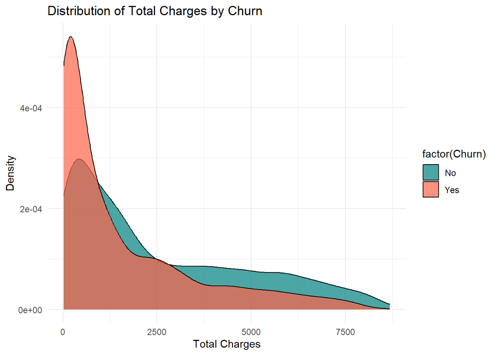

```r
# Total Charges vs Churn
ggplot(df1, aes(x = TotalCharges, fill = factor(Churn))) +
  geom_density(alpha = 0.7, color = 'black') +
  scale_fill_manual(values = c('#008080', '#FF6347')) +
  labs(title = 'Distribution of Total Charges by Churn', x = 'Total Charges', y = 'Density') +
  theme_minimal()
```

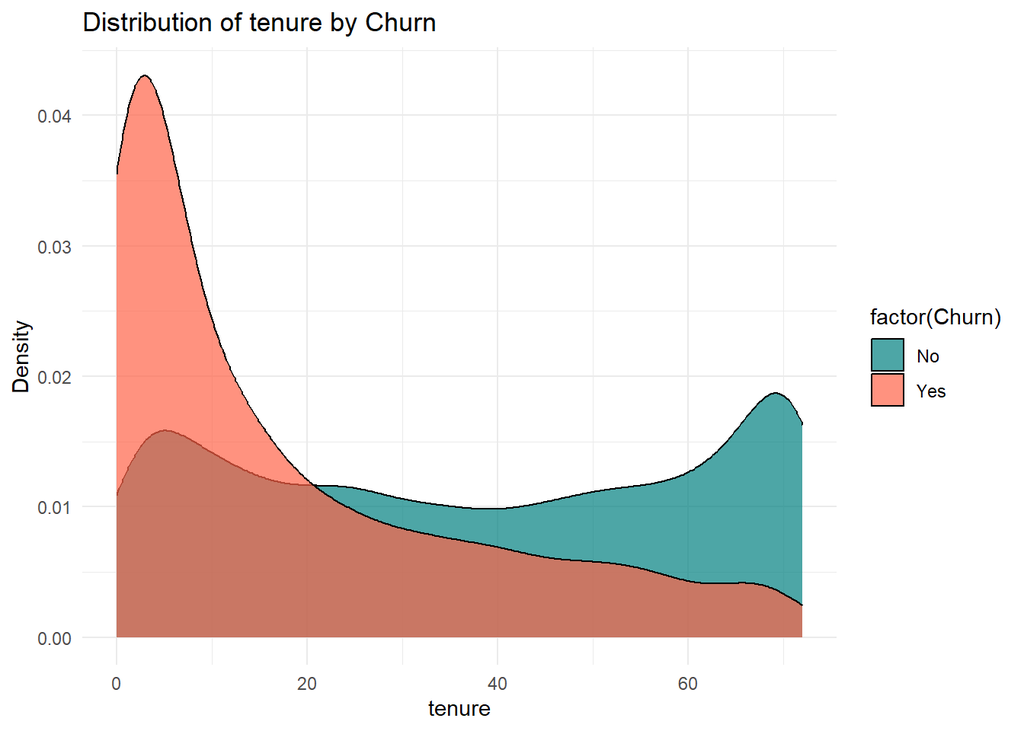

```r
# tenure vs Churn
ggplot(df1, aes(x = tenure, fill = factor(Churn))) +
  geom_density(alpha = 0.7, color = 'black') +
  scale_fill_manual(values = c('#008080', '#FF6347')) +
  labs(title = 'Distribution of tenure by Churn', x = 'tenure', y = 'Density') +
  theme_minimal()
```

- The longer the customer has been with the provider the more likely he will not churn.

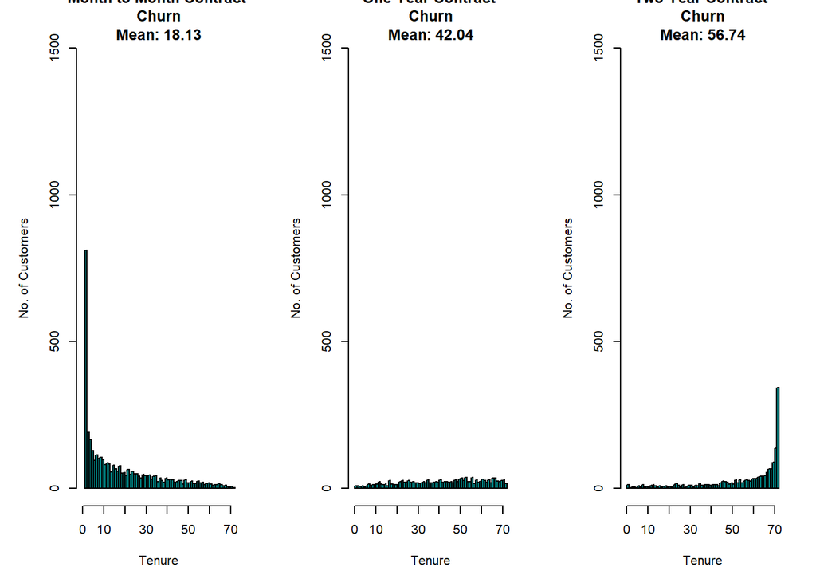

```r
# Assuming df is your data frame

# Convert 'Contract' to a factor with appropriate levels
df$Contract <- factor(df$Contract, levels = c("Month-to-month", "One year", "Two year"))

# Calculate mean tenures for different contract types
two_year_mean <- round(mean(df$tenure[df$Contract == "Two year"], na.rm = TRUE), 2)
month_mean <- round(mean(df$tenure[df$Contract == "Month-to-month"], na.rm = TRUE), 2)
year_mean <- round(mean(df$tenure[df$Contract == "One year"], na.rm = TRUE), 2)

# Create histograms for different contract types
par(mfrow = c(1, 3), mar = c(5, 5, 2, 2), xpd = TRUE)

# Function to handle potential issues in plotting histogram
plot_hist <- function(data, contract_type, mean_value) {
  if (length(data) > 0) {
    hist(data, main = paste(contract_type, "\nChurn\nMean:", mean_value),
         xlab = "Tenure", ylab = "No. of Customers", col = "#008080", breaks = 72,
         xlim = c(0, max(data, na.rm = TRUE)), ylim = c(0, 1500))
  } else {
    cat("No data for", contract_type, "\n")
  }
}

# Plot histograms
plot_hist(df$tenure[df$Contract == "Month-to-month"], "Month to Month Contract", month_mean)
plot_hist(df$tenure[df$Contract == "One year"], "One Year Contract", year_mean)
plot_hist(df$tenure[df$Contract == "Two year"], "Two Year Contract", two_year_mean)
```

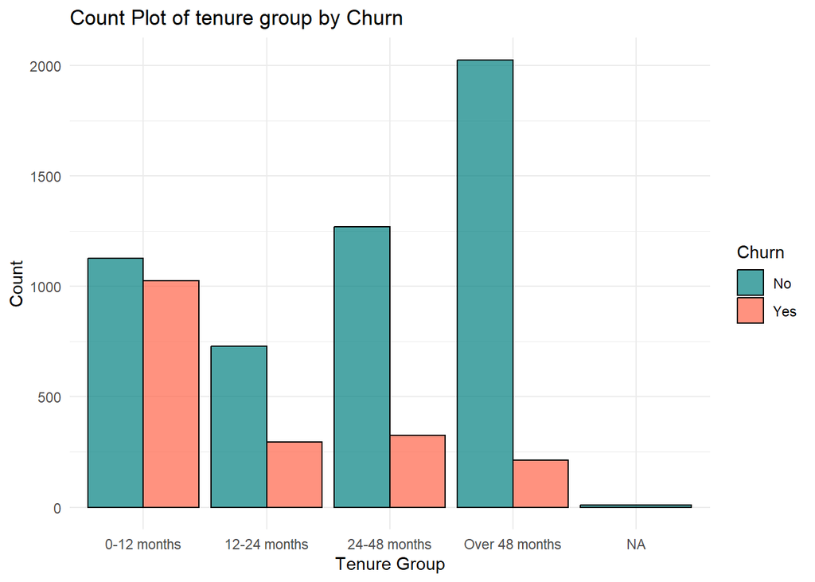

```r
df$tenure <- as.numeric(df$tenure)
# Create a categorical variable for tenure groups
df$tenure.group <- cut(df$tenure, breaks = c(0, 12, 24, 48, Inf),
                       labels = c("0-12 months", "12-24 months", "24-48 months", "Over 48 months"))

# Load required libraries
library(ggplot2)

# Create a count plot
ggplot(df, aes(x = tenure.group, fill = Churn)) +
  geom_bar(position = "dodge", color = "black", alpha = 0.7) +
  labs(title = "Count Plot of tenure group by Churn") +
  xlab("Tenure Group") +
  ylab("Count") +
  scale_fill_manual(values = c("#008080", "#FF6347")) +
  theme_minimal()
```

- The analysis gives a bigger picture. HIgher the tenure group, higher chances of retention and lesser chances of churn.

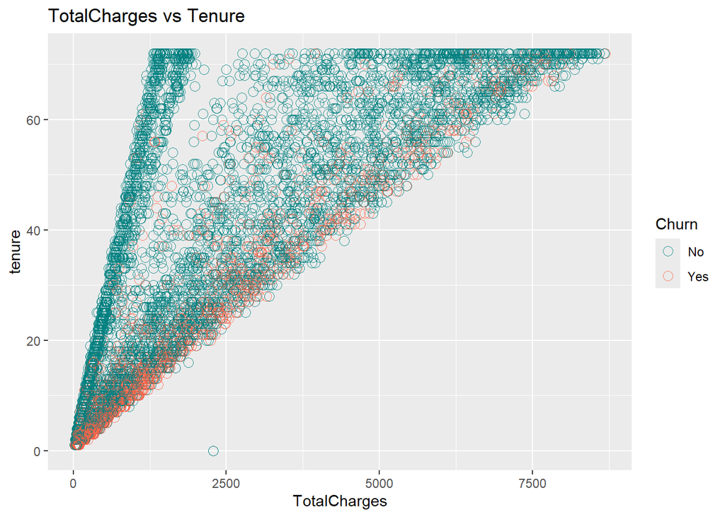

```r
# Assuming df is your data frame

library(ggplot2)

# Define the color palette
palette2 <- c('#008080', '#FF6347')

# Scatterplot for TotalCharges vs tenure
ggplot(df, aes(x = TotalCharges, y = tenure, color = Churn)) +
  geom_point(size = 3, alpha = 0.8, shape = 1, stroke = 0.5) +
  scale_color_manual(values = palette2) +
  labs(title = 'TotalCharges vs Tenure')
```

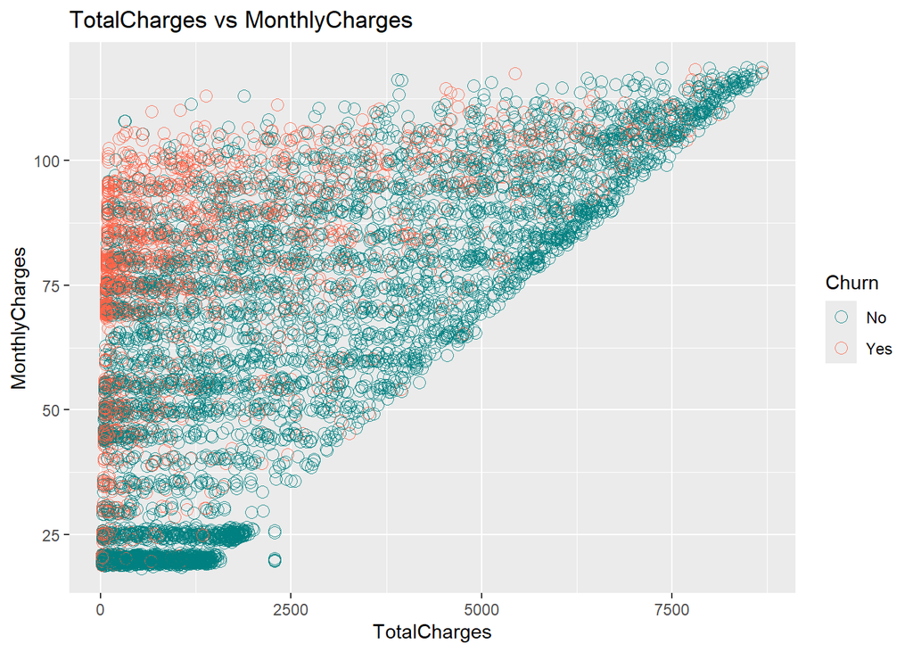

```r
# Scatterplot for TotalCharges vs MonthlyCharges
ggplot(df, aes(x = TotalCharges, y = MonthlyCharges, color = Churn)) +
  geom_point(size = 3, alpha = 0.8, shape = 1, stroke = 0.5) +
  scale_color_manual(values = palette2) +
  labs(title = 'TotalCharges vs MonthlyCharges')
```

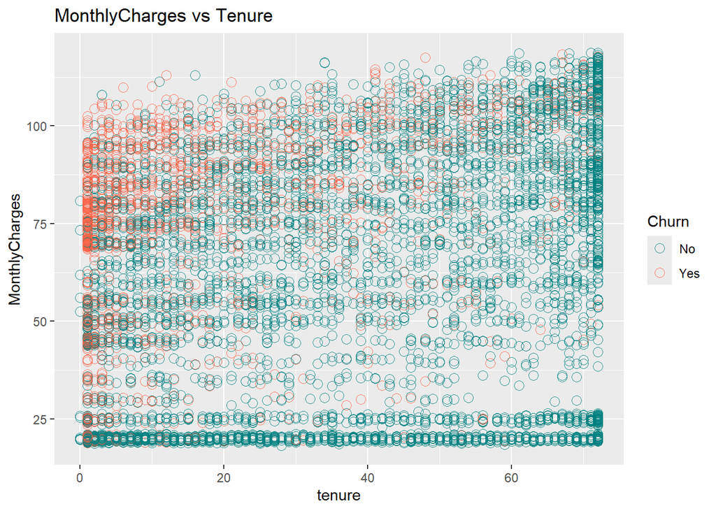

```r
# Scatterplot for MonthlyCharges vs tenure
ggplot(df, aes(x = tenure, y = MonthlyCharges, color = Churn)) +
  geom_point(size = 3, alpha = 0.8, shape = 1, stroke = 0.5) +
  scale_color_manual(values = palette2) +
  labs(title = 'MonthlyCharges vs Tenure')
```

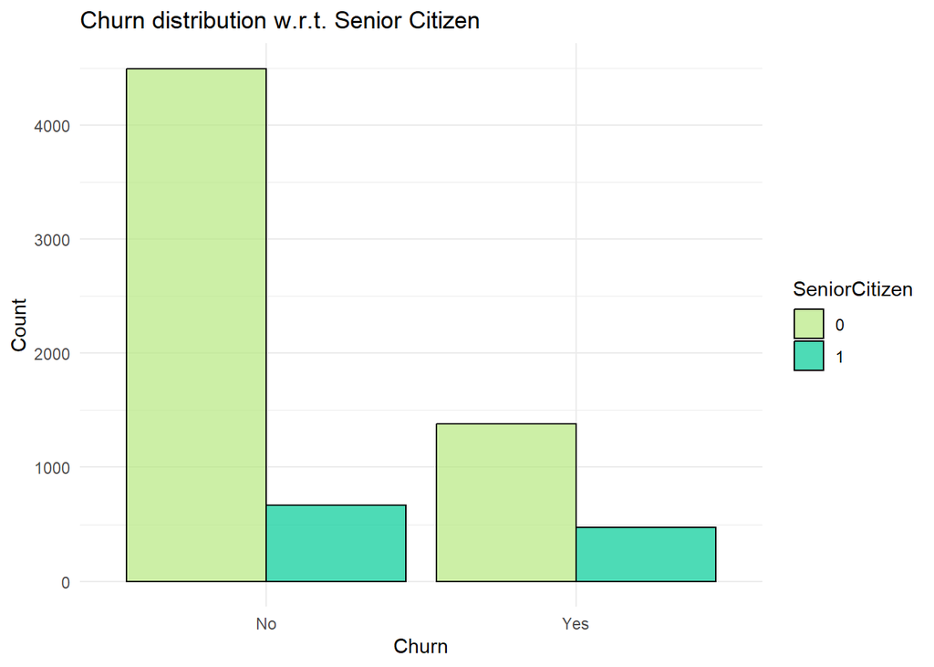

```r
# Plotting Senior Citizen Distribution

library(tidyverse)
library(magrittr)
# Convert SeniorCitizen to factor
df$SeniorCitizen <- factor(df$SeniorCitizen)
color_map <- c("1" = '#00CC96', "0" = '#B6E880')
df %>%
  ggplot(aes(x = Churn, fill = SeniorCitizen)) +
  geom_bar(position = "dodge", color = "black", alpha = 0.7) +
  labs(title = "Churn distribution w.r.t. Senior Citizen") +
  xlab("Churn") +
  ylab("Count") +
  scale_fill_manual(values = color_map) +
  theme_minimal()
```

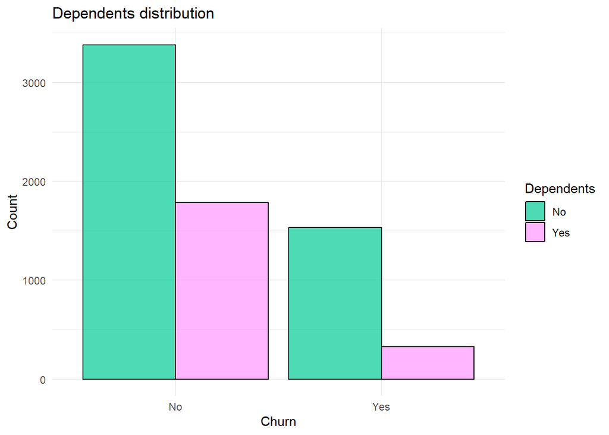

```r
# Plotting Dependents Distribution
color_map <- c("Yes" = "#FF97FF", "No" = "#00CC96")
df %>%
  ggplot(aes(x = Churn, fill = Dependents)) +
  geom_bar(position = "dodge", color = "black", alpha = 0.7) +
  labs(title = "Dependents distribution") +
  xlab("Churn") +
  ylab("Count") +
  scale_fill_manual(values = color_map) +
  theme_minimal()
```

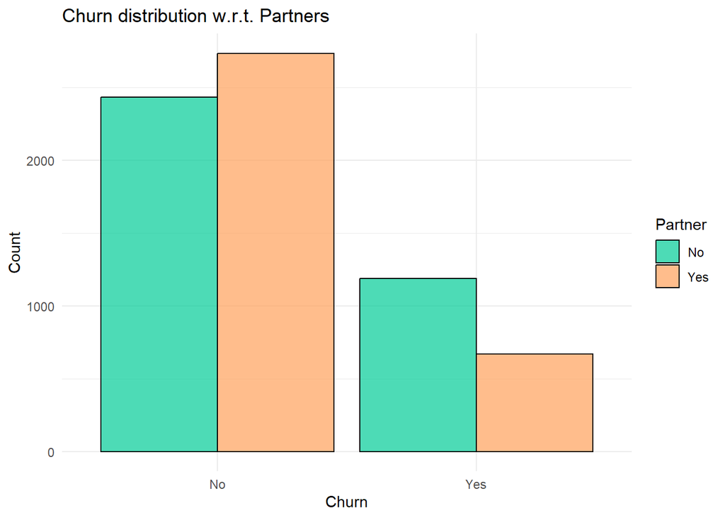

```r
# Plotting Partner Distribution
color_map <- c("Yes" = "#FFA15A", "No" = "#00CC96")
df %>%
  ggplot(aes(x = Churn, fill = Partner)) +
  geom_bar(position = "dodge", color = "black", alpha = 0.7) +
  labs(title = "Churn distribution w.r.t. Partners") +
  xlab("Churn") +
  ylab("Count") +
  scale_fill_manual(values = color_map) +
  theme_minimal()
```

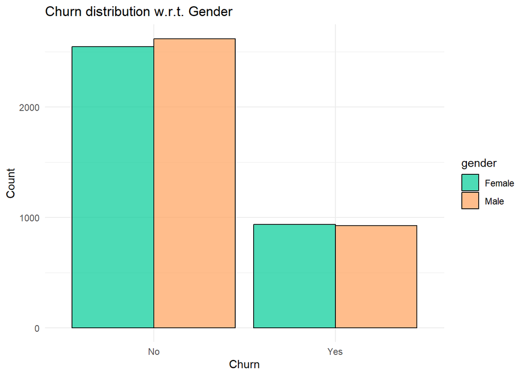

```r
# Plotting Gender Distribution
color_map <- c("Male" = "#FFA15A", "Female" = "#00CC96")
df %>%
  ggplot(aes(x = Churn, fill = gender)) +
  geom_bar(position = "dodge", color = "black", alpha = 0.7) +
  labs(title = "Churn distribution w.r.t. Gender") +
  xlab("Churn") +
  ylab("Count") +
  scale_fill_manual(values = color_map) +
  theme_minimal()
```

Provided services PhoneService, MultipleLines, InternetService, StreamingTV, StreamingMovies

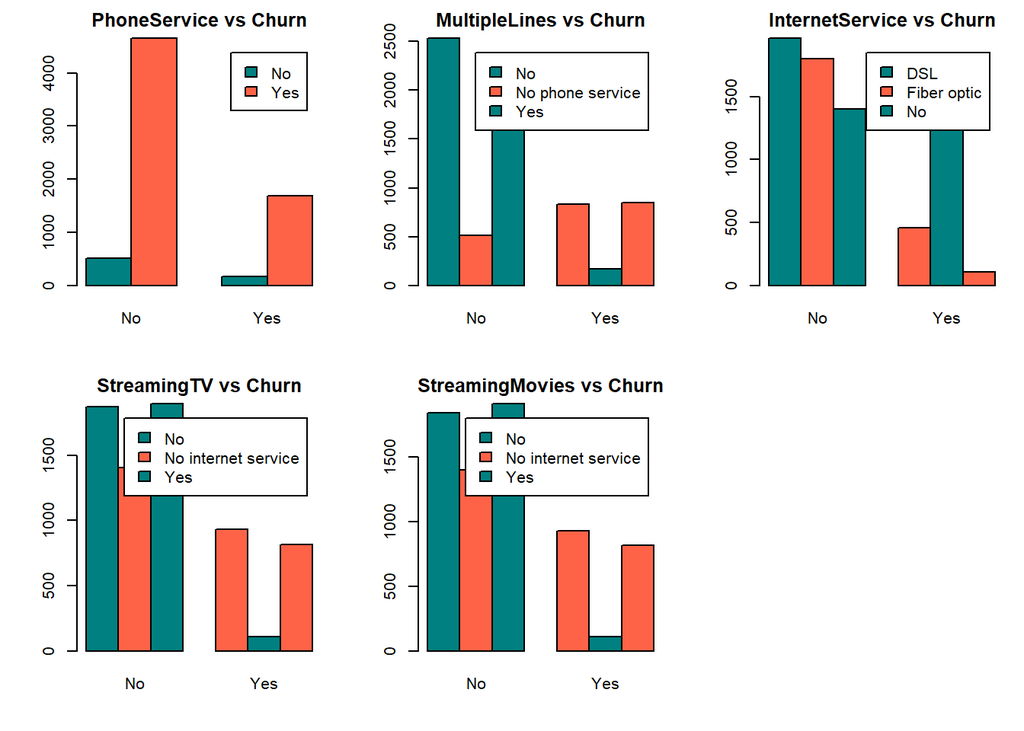

```r
# List of features
list2 <- c('PhoneService', 'MultipleLines', 'InternetService', 'StreamingTV', 'StreamingMovies')

# Create a multi-plot layout
par(mfrow=c(2,3), mar=c(4,4,2,1))

# Plot each feature against Churn
for (i in 1:length(list2)) {
  # Create a count plot
  counts <- table(df[, list2[i]], df$Churn)
  barplot(counts, beside=TRUE, col=palette2, main=paste(list2[i], 'vs Churn'), legend.text=TRUE)
}
```